# 3 Characterisation of PURA binding

Melina

03 October, 2022

# 1 What is done here?

- Types of bound genes
- Distribution of binding sites over gene regions (with and without normalisation for region length)
- Distribution of crosslink event over gene regions, metagene profile
- Distribution of binding sites per gene and in relation to TPM
- Relative maps of crosslink distribution
- GeneOntology and REACTOME enrichment analysis

# 2 Input

```r
# Clip data
binding_sites <-  readRDS("/Users/melinaklostermann/Documents/projects/PURA/Molitor-et-al-2022/binding_sites.rds")
CL_list <- readRDS("/Users/melinaklostermann/Documents/projects/PURA/Molitor-et-al-2022/bw_merges.rds")



# RNAseq
rnaseq_counts <- readRDS("/Users/melinaklostermann/Documents/projects/PURA/Molitor-et-al-2022/rnaseq_counts.rds")


# annotations
gff3 <- "/Users/melinaklostermann/Documents/projects/anno/GENCODEv31-p12/gencode.v31.annotation.gff3" # for cliProfiler
annotation <- readRDS("/Users/melinaklostermann/Documents/projects/PURA/Molitor-et-al-2022/annotation.rds")
anno_txdb <- loadDb("/Users/melinaklostermann/Documents/projects/PURA/Molitor-et-al-2022/annotation_txdb.db")
```

# 3 Bound Genes and regions

## 3.1 assign bound gene type

- many binding sites overlap with multiple genes (non codings!)
- in IGV it look like rather the non-coding RNA than the protein-coding RNA is bound in that case
- we therefore use a hieracry on gene types: lncRNA > miRNA > miscRNA > snRNA > snoRNA > protein-coding

```r
############################
# annote binding sites with the bound ( = overlapping) gene
################################
#  overlaps are resolved by:
# 1. for two genes of different type by the type hieracy
# 2. for to protein coding genes: in this chunk one protein coding gene is assigned at random in the next chunk the region hieracry is used to make this decision and the gene info is changed then


annotation_gene <- annotation[annotation$type=="gene"]

# overlaps of bs with any gene
ol <- findOverlaps(annotation_gene, binding_sites, ignore.strand=F)

# index binding sites
binding_sites$idx <-  1:NROW(binding_sites)

# get all possible regions overlapping with crosslinked nucleotide in a temporary file
binding_sites_temp1 <- binding_sites[subjectHits(ol)]
binding_sites_temp1 <- sortSeqlevels(binding_sites_temp1)
elementMetadata(binding_sites_temp1) <-  c(elementMetadata(binding_sites_temp1), elementMetadata(annotation_gene[queryHits(ol), c("gene_id", "gene_type", "gene_name")]))

table(binding_sites_temp1$gene_type)
```

```
##
##         lncRNA          miRNA       misc_RNA protein_coding       ribozyme
##           1857             16             47          59076             15
##         scaRNA         snoRNA          snRNA
##              3             15             73
```

```r
# chose for each binding site a gene from the highest possible hierarchy
# if two genes from the same type would be present the first one is chosen (randomly)
binding_sites_temp2 <- binding_sites_temp1 %>%
  as.data.frame(.) %>% # this file contains several entries for 1 binding site overlapping with more than one gene
  group_by(idx) %>% # the idx colum is an index of the binding sites
  arrange(factor(gene_type, levels = c("lncRNA", "miRNA", "miscRNA", "snRNA", "snoRNA", "protein_coding" )), .by_group = T) %>% # arrange by hierarcy
  dplyr::slice(1) # choose randomly  the first gene (the chosen gene is changed in the next chunk for protein coding genes)

binding_sites_temp2 <- makeGRangesFromDataFrame(binding_sites_temp2, keep.extra.columns = T)

table(binding_sites_temp2$gene_type)
```

```
##
##         lncRNA          miRNA       misc_RNA protein_coding         snoRNA
##           1854             16             19          55384             11
##          snRNA
##             57
```

```r
# non coding rnas "fake" region non coding
bs_temp_non_cod <- binding_sites_temp2[binding_sites_temp2$gene_type!= "protein_coding",] %>% makeGRangesFromDataFrame(., keep.extra.columns = T)
bs_temp_non_cod$type <- "non_coding"
```

## 3.2 Binding site region by hiercary approach

- Overlap Bs with mutiple regions and choose one with highest priority
- hieracry: “three_prime_UTR” > “five_prime_UTR” > “CDS” > “intron”
- only done for protein-coding genes

## 3.3 Total number of binding sites per region

```r
# classify only protein coding genes, regions only from bound genes
anno_regions <- annotation[annotation$gene_type == "protein_coding" & annotation$type %in% c("three_prime_UTR", "five_prime_UTR", "CDS") ]

#get introns
introns <- intronsByTranscript(anno_txdb, use.names=T) %>% unlist(.)
introns$type = "intron"

anno_regions <- c(anno_regions, introns)

#overlaps of binding sites with protein coding genes
binding_sites_temp_pc <- binding_sites_temp2[binding_sites_temp2$gene_type=="protein_coding"]


ol_bs <- findOverlaps(anno_regions, binding_sites_temp_pc-2, ignore.strand = FALSE)


# get all possible regions overlapping with bs
binding_sites_temp_pc2 <- binding_sites_temp_pc[subjectHits(ol_bs)]
binding_sites_temp_pc2 <- sortSeqlevels(binding_sites_temp_pc2)

# get possible region and transcript annotation of bs
anno_bs <- elementMetadata(anno_regions[queryHits(ol_bs)]) %>%
  as.data.frame(.) %>%
  dplyr::select(c("type", "gene_id"))

# and add to temp binding sites
colnames(anno_bs) <- c("type", "gene_id.from_region")
elementMetadata(binding_sites_temp_pc2) <- c(elementMetadata(binding_sites_temp_pc[subjectHits(ol_bs)]), anno_bs)


# choose type highest in hiearcy
binding_sites_temp_pc3 <- as.data.frame(binding_sites_temp_pc2) %>%
    mutate(., gene_id = gene_id.from_region ) %>% # this throws out regions that overlap with non-coding RNAs, with this line no binding sites in introns!!!
  group_by(idx) %>% # specific id per binding site
  arrange(factor(type, levels = c("three_prime_UTR", "five_prime_UTR", "CDS", "intron")), .by_group = T) %>%
  dplyr::slice(1) # arrange by region, select first, transcript info is ignored here

binding_sites_temp_pc3 <- makeGRangesFromDataFrame(binding_sites_temp_pc3, keep.extra.columns = T)
sortSeqlevels(binding_sites_temp_pc3)
```

```
## GRanges object with 53074 ranges and 12 metadata columns:
##           seqnames              ranges strand |     score  clp_rep1  clp_rep2
##              <Rle>           <IRanges>  <Rle> | <numeric> <numeric> <numeric>
##       [1]     chr1     1520189-1520193      + |   11.3361         0        23
##       [2]     chr1     2308661-2308665      + |   12.7161        10         0
##       [3]     chr1     2308683-2308687      + |   20.3584        18        13
##       [4]     chr1     2403329-2403333      + |   17.0852         4        16
##       [5]     chr1     2403349-2403353      + |   10.1181         6         6
##       ...      ...                 ...    ... .       ...       ...       ...
##   [53070]     chrX   72272713-72272717      - | 68.614700        88        84
##   [53071]     chr1   25228173-25228177      - |  8.268300         7         7
##   [53072]     chr1   67430004-67430008      - | 13.275100        13        16
##   [53073]     chr3 196937045-196937049      - |  2.949730        16         0
##   [53074]     chr9   35685315-35685319      - |  0.940137         7        16
##            clp_rep3  clp_rep4     names       idx         gene_id
```

[output cut: 27 more lines]

```r
# merge BS from non-coding RNAs and binding sites with specific regions
binding_sites_with_regions <- c(binding_sites_temp_pc3, bs_temp_non_cod)


# some protein coding genes not have a region, because no trustworth transcript is annotated in this position of the gene
bs_without_region <- binding_sites[-queryHits(findOverlaps(binding_sites, binding_sites_with_regions))]
```

## 3.4 Plot total number of gene type

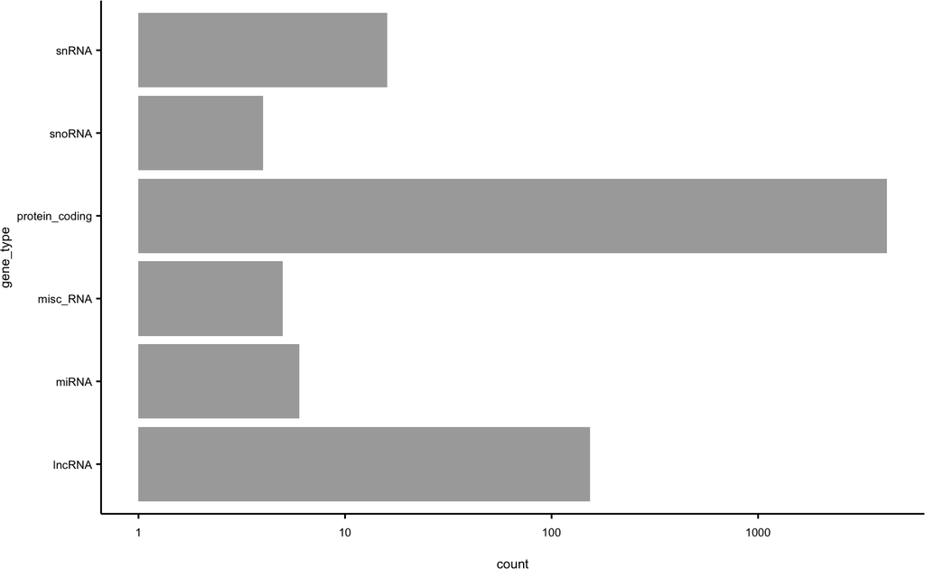

```r
###################
# make plots
##################

# gene types

bound_genes_gg <- as.data.frame(binding_sites_with_regions) %>%
  filter(!duplicated(gene_id))

ggplot(bound_genes_gg, aes(x = gene_type))+
  geom_bar(fill = "darkgrey")+
  scale_y_log10()+
  coord_flip()+
  theme_paper()
```

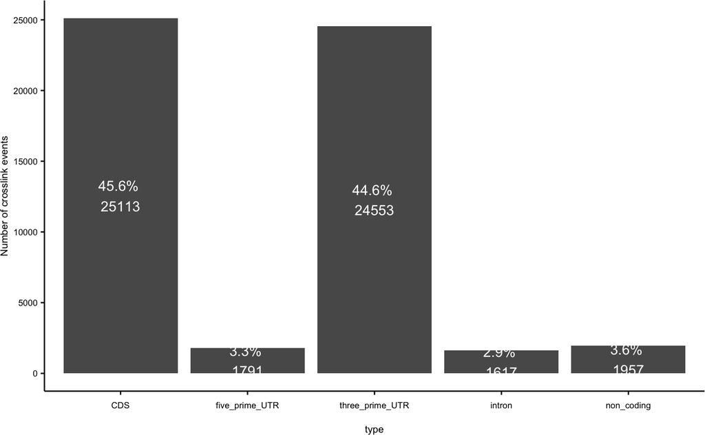

```r
ggsave(paste0(outpath, "gene_types.pdf"), width = 5 , height  = 5, units = "cm")

# gene regions

binding_sites_gg <- as.data.frame(binding_sites_with_regions)

ggplot(binding_sites_gg, aes(x = type))+
  geom_bar()+
  stat_count(aes(label=paste0(
    sprintf("%1.1f", ..count../sum(..count..)*100),
                              "% \n", ..count..), y=0.5*..count..),
             geom="text", colour="white", size=4, position=position_dodge(width=1)) +
  theme_paper()+
  ylab("Number of crosslink events")
```

```r
ggsave(paste0(outpath, "gene_regions.pdf"), width = 5 , height  = 5, units = "cm")
```

```r
# final numbers
table(binding_sites_with_regions$region)
```

```
## < table of extent 0 >
```

```r
table(binding_sites_with_regions[!duplicated(binding_sites_with_regions$gene_id),]$gene_type)
```

```
##
##         lncRNA          miRNA       misc_RNA protein_coding         snoRNA
##            154              6              5           4207              4
##          snRNA
##             16
```

```r
# clean up unnecessary columns
colnames(elementMetadata(binding_sites_with_regions)) <- c(colnames(elementMetadata(binding_sites_with_regions))[1:10], "region", "")
elementMetadata(binding_sites_with_regions) <- elementMetadata(binding_sites_with_regions)[c(1:11)]
```

## 3.5 Normlisation for region length

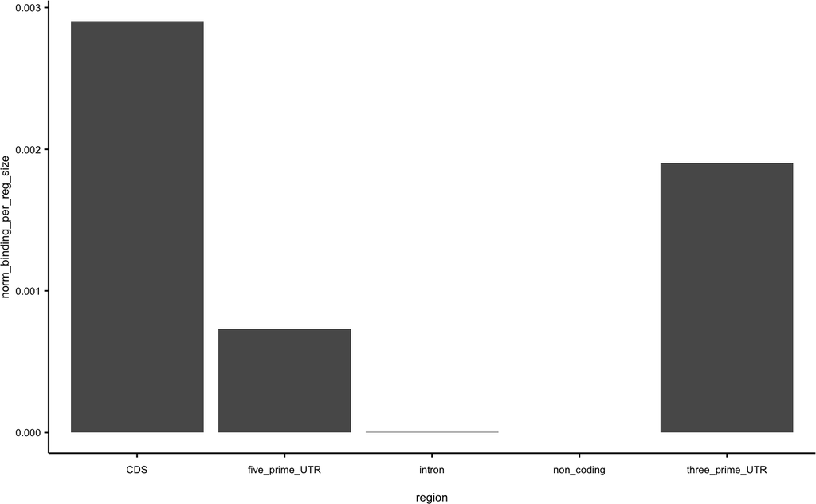

```r
# classify only protein coding genes
anno_regions_r <- GenomicRanges::reduce(anno_regions)

# annotate the whole annotation to a specific region by hierarcy

# get all 3'utrs
utr3 <- anno_regions[anno_regions$type=="three_prime_UTR"] %>%
  GenomicRanges::reduce()
# remove 3'utr regions from genome coordiantes left to assign
anno_left <- GenomicRanges::setdiff(anno_regions_r, utr3, ignore.strand=FALSE)

# get 5'UTRs from genome coordiantes left to assign
utr5 <- GenomicRanges::intersect(anno_left,
                                 anno_regions[anno_regions$type=="five_prime_UTR"] ) %>%
  GenomicRanges::reduce()
# remove 5'utr regions from genome coordiantes left to assign
anno_left <- GenomicRanges::setdiff(anno_left, utr5, ignore.strand=FALSE)


cds <- GenomicRanges::intersect(anno_left,
                                anno_regions[anno_regions$type=="CDS"] ) %>%
  GenomicRanges::reduce()
anno_left <- GenomicRanges::setdiff(anno_left, cds, ignore.strand=FALSE)


intron <- GenomicRanges::intersect(anno_left,
                                   anno_regions[anno_regions$type=="intron"] ) %>%
  GenomicRanges::reduce()
anno_left <- GenomicRanges::setdiff(anno_left, intron, ignore.strand=FALSE)

# get lenght of regions for as norm factor
norm_df <- data.frame(region = c("three_prime_UTR", "five_prime_UTR", "CDS", "intron"),
                      width = c(sum(width(utr3)), sum(width(utr5)), sum(width(cds)), sum(width(intron))))

# normalise bs in regions by norm factor
norm_regions <- binding_sites_with_regions %>% as.data.frame(.) %>%
  group_by(region) %>%
  summarize(nts_in_BS = sum(width-2)) %>%
  left_join(norm_df, by = "region") %>%
  mutate(norm_binding_per_reg_size = nts_in_BS / width) # mal 1000 per kb


# plot normed gene regions
ggplot(norm_regions, aes(x=region, y = norm_binding_per_reg_size))+
  geom_col()+
  theme_paper()
```

```r
ggsave(paste0(outpath, "gene_regions_norm.pdf"), width = 5 , height  = 5, units = "cm")
```

## 3.6 Strongest binding site per gene

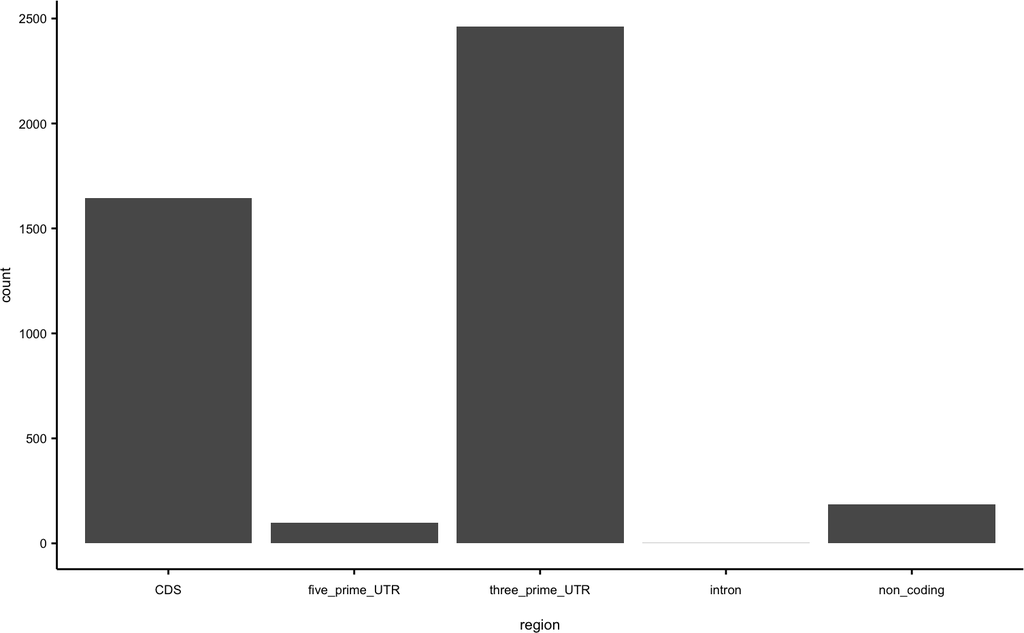

```r
# check strongest binding site per gene, to see if distribution between regions shifts
# --> the strongest BS per gene is more often in the 3'UTR
strongest_BS <- binding_sites_with_regions %>%
  as.data.frame(.) %>%
  group_by(gene_id) %>%
  arrange(desc(score)) %>%
  dplyr::slice(1) %>%
  ungroup()

ggplot(strongest_BS, aes(x=region))+
  geom_bar()+
  theme_paper()
```

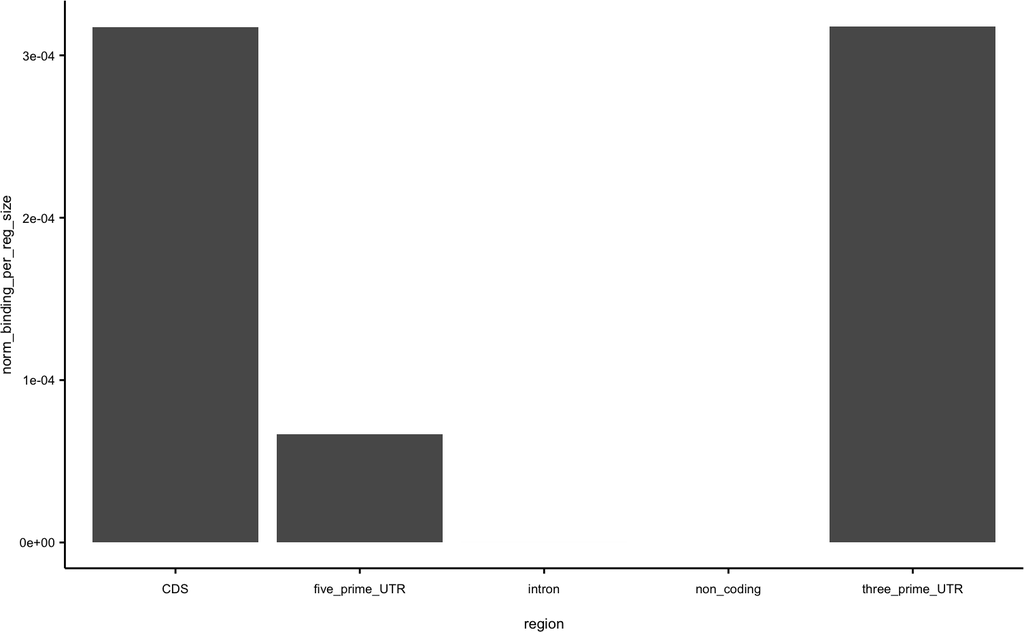

```r
strongest_BS_norm <- strongest_BS %>%
  group_by(region)%>%
  summarize(nts_in_BS = sum(width)) %>%
  left_join(., norm_df, by = "region") %>%
  mutate(norm_binding_per_reg_size = nts_in_BS / width)


ggplot(strongest_BS_norm, aes(x=region, y = norm_binding_per_reg_size))+
  geom_col()+
  theme_paper()
```